# Emission by depth regime: when read counts matter, and when a hard genotype is enough

The HMM emission is a depth-driven choice — BetaBinomial counts earn their keep only in an intermediate band

Author

Fausto Rodríguez-Zapata

Published

June 26, 2026

**Context.** A unified ancestry-caller engine (RTIGER / nilHMM / Skim-BIN as one duration-aware HMM, see `generative_vs_discriminative_callers`) keeps **3 hidden genotype states** (REF / HET / ALT) and a shared **duration/rigidity** layer, and treats the **emission as a swappable module**. This note pins down *which* emission to use *when*: the choice is driven almost entirely by **read depth**, with the BetaBinomial count model earning its keep only in an intermediate band. Below it the data is degenerate; above it the count model saturates into a hard genotype. Memory: `rtiger-betabinomial-cost`, `nilhmm-counts-path`, `bzea-skim-bulked-bc2s2`, `molbreeding-45k-source5`.

# 1. The emission is the swappable axis

The three callers differ mainly in their emission; the 3 states and the duration layer are shared. The candidate emissions:

| Observation | Emission family | Carries depth-confidence? |
| --- | --- | --- |
| read counts $(n_\text{ref}, n_\text{alt})$ | **BetaBinomial** (state means $\theta=\{\text{err},\,0.5,\,1-\text{err}\}$) | **yes** — sharpens with $n$ |
| hard genotype $\in\{0,1,2\}$ | **categorical** + genotype-error matrix | no (a call is a call) |
| imputed dosage $\in[0,2]$ | Gaussian/Beta centred at $0/1/2$ | yes, *if* it carries imputation uncertainty |

The claim of this note: **counts vs. hard-GT is not a modelling preference — it is dictated by depth.**

# 2. The depth axis

| Depth | What is true | Right emission |
| --- | --- | --- |
| $\ll 1\times$ (skim, ~0.4×) | counts needed, but **HET is invisible** — a single alt read can’t distinguish HET from donor-hom (data-limited, *not* emission-limited) | BetaBinomial counts (best available; still degenerate) |
| $\sim 1\text{–}20\times$ (BRB-seq, ~2.8×) | depth-weighting is genuinely informative; HET/HOM resolvable | **BetaBinomial counts** |
| $\gtrsim 20\times$ (target sequencing / MolBreeding) | **saturated** — the count likelihood collapses to a near-delta = a hard call | **categorical hard GT** (equivalent *and* cheaper) |

The BetaBinomial matters **only in the middle band.** The two boundaries are the interesting part.

## 2.1 Upper boundary — why ≥20× saturates to a hard call

The BetaBinomial emission cost scales with the **number of distinct $(n, k)$ count pairs, which scales with coverage** — so RTIGER and the optimized nilHMM **cap depth at ~20–30×** (`rtiger-betabinomial-cost`). That cap is statistically free for exactly the reason it makes hard GT viable: **at $\geq 20\times$ the emission is so peaked that the genotype is already certain.** The likelihood over $\{\text{ref},\text{het},\text{alt}\}$ becomes a delta on one state → a hard call. So above the cap, **counts and hard GT carry the same information**, and hard GT is strictly cheaper (a $3\times3$ error matrix vs. per-pair BetaBinomial). You are not *approximating* the count model with a hard genotype — at saturation the count model *is* a hard genotype.

## 2.2 Lower boundary — why ≪1× is degenerate (and the emission can’t fix it)

At depth ~1, a single observed allele is consistent with **both** HET ($\theta=0.5$) and the matching homozygote. A lone alt read is actually *more* likely under donor-hom ($\theta\approx1$) than under HET ($0.5$), so HET gets misassigned to hom. This is the **depth-1 HET/HOM degeneracy** (`bzea-skim-bulked-bc2s2`, `nilhmm-counts-path`): it is a **data** limit, not an emission-model limit — no choice of emission recovers information the reads don’t contain.

# 3. The picture: discriminability vs. depth

For a marker whose true genotype is HET ($\theta=0.5$) vs. donor-hom ($\theta\approx1$), the probability that the MAP call is **correct**, as a function of depth:

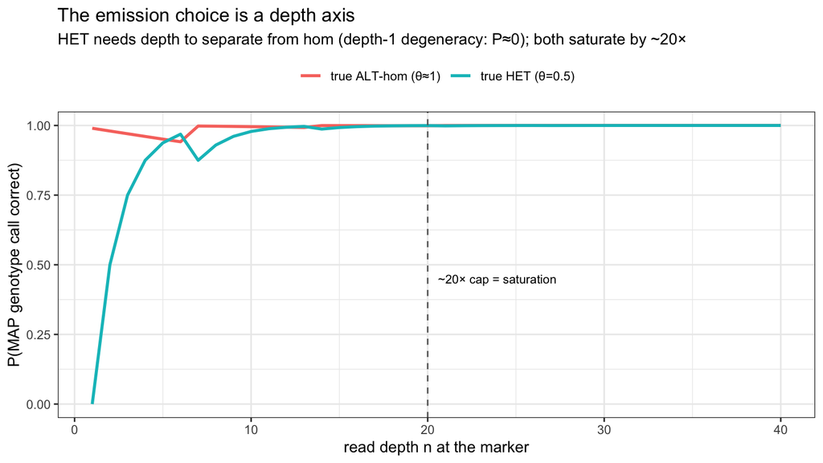

```r
library(ggplot2)
err <- 0.01
th  <- c(ref = err, het = 0.5, alt = 1 - err)     # emission alt-fraction per hidden state

# P(MAP call == truth) for a given true state, as a function of depth n (flat prior)
p_correct <- function(true_state, n) {
  ks <- 0:n
  w  <- dbinom(ks, n, th[[true_state]])             # distribution of observed alt count
  L  <- sapply(th, function(p) dbinom(ks, n, p))    # (n+1) x 3 likelihoods
  call <- colnames(L)[max.col(L, ties.method = "first")]
  sum(w[call == true_state])
}
ns <- 1:40
df <- rbind(
  data.frame(depth = ns, p = vapply(ns, function(n) p_correct("het", n), 0), state = "true HET (θ=0.5)"),
  data.frame(depth = ns, p = vapply(ns, function(n) p_correct("alt", n), 0), state = "true ALT-hom (θ≈1)"))

ggplot(df, aes(depth, p, colour = state)) +
  geom_line(linewidth = 1) +
  geom_vline(xintercept = 20, linetype = "dashed", colour = "grey40") +
  annotate("text", x = 20.6, y = 0.45, label = "~20× cap = saturation", hjust = 0, size = 3) +
  scale_y_continuous(limits = c(0, 1)) +
  labs(x = "read depth n at the marker", y = "P(MAP genotype call correct)", colour = NULL,
       title = "The emission choice is a depth axis",
       subtitle = "HET needs depth to separate from hom (depth-1 degeneracy: P≈0); both saturate by ~20×") +
  theme_bw() + theme(legend.position = "top")
```

Read it: **donor-hom is callable even at depth 1** (≈0.99); **HET is essentially uncallable at depth 1** (P≈0 — the degeneracy) and only becomes reliable past several ×, with **both saturated by ~20×**. The middle of that curve is the only place the BetaBinomial’s depth-weighting does work a hard call couldn’t.

# 4. Mapping to our three platforms

| Source | Depth | Regime | Emission |
| --- | --- | --- | --- |
| **Skim** (SNP50K) | ~0.4× | degenerate (HET invisible) | BetaBinomial counts — best available, still degenerate |
| **BRB-seq** | ~2.8× | intermediate | **BetaBinomial counts** — the band where they pay off |
| **MolBreeding** (target sequencing, 45K) | genotyping assay, high | **saturated** | **categorical hard GT** — equivalent + cheaper |

MolBreeding is the **saturated** regime: the BetaBinomial degenerates to a hard call by construction, so the categorical-GT emission (Holland’s original nilHMM GT path — the one we abandoned *only* because skim GT is 73% missing) is the correct, native, efficient choice there.

# 5. Implications

- **The emission selector is a depth rule**, not a taste: `depth-saturated (≥~20×) → categorical hard GT; intermediate (~1–20×) → BetaBinomial counts; (imputed → Gaussian dosage)`.
- **MolBreeding → hard GT.** The GATK count-table built for it (`molbreeding-45k-source5`) was needed for the uniform schema/liftover, but the *caller* can run straight off the genotypes; same answer, less machinery. Running it through *both* emissions is a built-in consistency check on the GT path (which skim could never exercise).
- **Skim’s problem is not the emission.** No emission recovers the HET/HOM split at depth 1; the honest move is the binary teosinte/B73 collapse (`elai_admixture_mapping_plan`), or higher depth (BRB).
- **Imputed dosage is a separate axis.** LD-aware imputation can lift a low-depth source toward the saturated regime *without* more reads (it borrows information across markers/individuals), feeding a Gaussian-dosage emission — the one way to escape the lower-boundary degeneracy short of sequencing deeper.

# 6. Caveats

- **Heterogeneous depth.** “≥20× → hard GT” assumes roughly uniform high depth. If a source has a low-depth tail, those markers still want counts; a categorical emission **with an error matrix** recovers most of it, and you can keep counts for the low tail if it matters.
- **Decision boundaries.** Even at high depth, a marker with $k/n$ near a state boundary (paralogs, contamination) is genuinely ambiguous; the error matrix in the categorical emission models the miscall rate, so little is lost.
- **The states and duration layer are unchanged** across all of this — only $p(\text{obs}\mid \text{state})$ swaps. That is the whole point of factoring the engine this way.